# Everyday Moments and The Mind

- Show All Code
- Hide All Code
- View Source

PSY 120L Reproducible Analysis Report

Author

Paulina Amador

Published

June 7, 2026

## About This Report

This report examines whether a brief outdoor break improves working memory compared to staying indoors. It also explores whether stress levels and sex affect memory performance.

## Study Overview

This study examined whether brief outdoor exposure improved working memory performance compared to an indoor environment and whether these effects differed by perceived stress levels and sex.

The design included one manipulated independent variable and two categorical grouping variables

*Environmental condition: outdoor exposure versus indoor exposure

*Perceived stress group:lower perceived stress versus higher perceived stress

*Sex: male versus female

## Setup and Software Environment

*This section imports the packages needed for data preparation, scale development, statistical analyses, estimated marginal means, and data visualization*

**Load Packages**

```r
library(tidyverse)  # data manipulation + plotting
library(psych)      # scale construction + reliability
library(afex)       # ANOVA models + effect sizes
library(emmeans)    # estimated marginal means + confidence intervals
```

## Data Source and Analysis Dataset

The dataset was imported from the project data folder. The imported dataset was saved as study_raw so that the original file remained unchanged throughout the report.

A smaller analysis dataset was then created for the current study. This dataset retained the environmental condition variables, demographic variables, perceived stress items, and working memory measures needed for variable preparation and analysis.

### Import Dataset

```r
study_raw <- read_csv("data/moments_mind_data.csv")
```

### Check Imported Dataset

```r
dim(study_raw)
```

```
[1] 84 40
```

```r
names(study_raw)
```

```
 [1] "StartDate"                  "EndDate"
 [3] "Duration (in seconds)"      "Finished"
 [5] "RecordedDate"               "Consent"
 [7] "Timing_Outdoor_First Click" "Timing_Outdoor_Last Click"
 [9] "Timing_Outdoor_Page Submit" "Timing_Outdoor_Click Count"
[11] "Timing_Indoor_First Click"  "Timing_Indoor_Last Click"
[13] "Timing_Indoor_Page Submit"  "Timing_Indoor_Click Count"
[15] "QID34"                      "Break_First Click"
[17] "Break_Last Click"           "Break_Page Submit"
[19] "Break_Click Count"          "Answer1"
[21] "Answer2"                    "Answer3"
[23] "Answer4"                    "Answer5"
[25] "Answer6"                    "Answer7"
[27] "Answer8"                    "PSS_1"
[29] "PSS_2"                      "PSS_3"
[31] "PSS_4"                      "PSS_5"
[33] "PSS_6"                      "PSS_7"
[35] "PSS_8"                      "PSS_9"
[37] "PSS_10"                     "sex"
[39] "age"                        "condition"
```

```r
head(study_raw)
```

```
# A tibble: 6 × 40
  StartDate    EndDate      Duration (in seconds…¹ Finished RecordedDate Consent
  <chr>        <chr>                         <dbl>    <dbl> <chr>          <dbl>
1 5/7/26 12:14 5/7/26 12:30                    910        1 5/7/26 12:30       1
2 5/7/26 13:01 5/7/26 13:12                    648        1 5/7/26 13:12       1
3 5/7/26 16:39 5/7/26 17:00                   1310        1 5/7/26 17:00       1
4 5/7/26 19:34 5/7/26 19:54                   1191        1 5/7/26 19:54       1
5 5/7/26 22:33 5/7/26 22:49                    926        1 5/7/26 22:49       1
6 5/7/26 23:15 5/7/26 23:29                    872        1 5/7/26 23:29       1
# ℹ abbreviated name: ¹`Duration (in seconds)`
# ℹ 34 more variables: `Timing_Outdoor_First Click` <dbl>,
#   `Timing_Outdoor_Last Click` <dbl>, `Timing_Outdoor_Page Submit` <dbl>,
#   `Timing_Outdoor_Click Count` <dbl>, `Timing_Indoor_First Click` <dbl>,
#   `Timing_Indoor_Last Click` <dbl>, `Timing_Indoor_Page Submit` <dbl>,
#   `Timing_Indoor_Click Count` <dbl>, QID34 <chr>, `Break_First Click` <lgl>,
#   `Break_Last Click` <lgl>, `Break_Page Submit` <lgl>, …
```

The import checks confirm that the dataset loaded successfully, show the number of rows and columns, and display the variable names available in the original dataset.

### Create Analysis Dataset

```r
study_vars <- c(
  "condition", "sex", "age",

  "Answer1", "Answer2", "Answer3", "Answer4",
  "Answer5", "Answer6", "Answer7", "Answer8",

  "PSS_1", "PSS_2", "PSS_3", "PSS_4", "PSS_5",
  "PSS_6", "PSS_7", "PSS_8", "PSS_9", "PSS_10"
)

study_data <- study_raw %>%
  select(all_of(study_vars)) %>%
  mutate(
    across(everything(), as.numeric)
  )
```

### Check Analysis Dataset

```r
length(study_vars)
```

```
[1] 21
```

```r
dim(study_data)
```

```
[1] 84 21
```

```r
names(study_data)
```

```
 [1] "condition" "sex"       "age"       "Answer1"   "Answer2"   "Answer3"
 [7] "Answer4"   "Answer5"   "Answer6"   "Answer7"   "Answer8"   "PSS_1"
[13] "PSS_2"     "PSS_3"     "PSS_4"     "PSS_5"     "PSS_6"     "PSS_7"
[19] "PSS_8"     "PSS_9"     "PSS_10"
```

The analysis dataset contains the variables required for the report.The checks confirm the number of selected variables, the dimensions of the analysis dataset, and the final variable names carried forward into the preparation and analysis sections.

## Variable Preparation

This section prepares the variables used in the primary analyses.The original imported dataset was left unchanged;all prepared variables were created in the working analysis dataset,study_data.

### Prepare Participant ID and Experimental Condition

```r
study_data <- study_data %>%
  mutate(
    id = row_number(),
    condition = factor(
      condition,
      levels = c(0, 1),
      labels = c("Indoor", "Outdoor")
    ),
    sex = factor(
      sex,
      levels = c(1, 2),
      labels = c("Male", "Female")
    )
  )
```

The environmental condition variable was recorded as a labeled factor with two levels:Indoor and Outdoor. A participant ID variable was also created to ensure that each row in the analysis dataset had a unique identifier.

### Check Experimental Condition Coding

```r
study_data %>%
  count(condition) %>%
  knitr::kable(
    col.names = c("Condition", "n")
  )
```

| Condition | n |
| --- | --- |
| Indoor | 43 |
| Outdoor | 41 |

The condition check confirms the number of participants assigned to each environmental condition, including the indoor and outdoor exposure groups.

### Check Prepared Analysis Dataset

```r
dim(study_data)
```

```
[1] 84 22
```

```r
names(study_data)
```

```
 [1] "condition" "sex"       "age"       "Answer1"   "Answer2"   "Answer3"
 [7] "Answer4"   "Answer5"   "Answer6"   "Answer7"   "Answer8"   "PSS_1"
[13] "PSS_2"     "PSS_3"     "PSS_4"     "PSS_5"     "PSS_6"     "PSS_7"
[19] "PSS_8"     "PSS_9"     "PSS_10"    "id"
```

The prepared analysis dataset contains the variables needed for scale construction, descriptive statistics, and primary analyses.

### Score Backward Digit Span

```r
answer_cols <- paste0("Answer", 1:8)
correct_answer8 <- "485268572"

study_data <- study_data %>%
  mutate(
    Answer8_clean = str_remove(as.character(Answer8), "\\.0$"),
    span_score = 8 - rowSums(
      across(
        all_of(answer_cols),
        ~ is.na(.x) | str_trim(as.character(.x)) == ""
      )
    ),
    span_score = if_else(
      span_score == 8 & Answer8_clean == correct_answer8,
      9,
      span_score
    )
  ) %>%
  filter(span_score != 0)
```

The backward digit span score served as the primary working memory outcome variable. Higher scored indicated better working memory performance and greater ability to temporarily store and manipulate information.

### Check Backward Digit Span Scores

```r
study_data %>%
  count(span_score) %>%
  knitr::kable(
    col.names = c("Backward Digit Span Score", "n")
  )
```

| Backward Digit Span Score | n |
| --- | --- |
| 1 | 10 |
| 2 | 8 |
| 3 | 10 |
| 4 | 22 |
| 5 | 23 |
| 6 | 6 |
| 7 | 4 |
| 9 | 1 |

```r
summary(study_data$span_score)
```

```
   Min. 1st Qu.  Median    Mean 3rd Qu.    Max.
  1.000   3.000   4.000   3.952   5.000   9.000
```

### Reverse-Code Scale Items

Items requiring reverse coding were transformed before scale scores were calculated. For the 10-item Perceived Stress Scale, items 4,5,7, and 8 were reverse coded prior to computing total stress scores.

```r
study_data <- study_data %>%
  mutate(
    PSS_4r = 4 - PSS_4,
    PSS_5r = 4 - PSS_5,
    PSS_7r = 4 - PSS_7,
    PSS_8r = 4 - PSS_8
  )
```

### Check Reverse Coding

```r
study_data %>%
  select(
    PSS_4, PSS_4r,
    PSS_5, PSS_5r,
    PSS_7, PSS_7r,
    PSS_8, PSS_8r
  ) %>%
  head(10) %>%
  knitr::kable()
```

| PSS_4 | PSS_4r | PSS_5 | PSS_5r | PSS_7 | PSS_7r | PSS_8 | PSS_8r |
| --- | --- | --- | --- | --- | --- | --- | --- |
| 3 | 1 | 3 | 1 | 3 | 1 | 2 | 2 |
| 3 | 1 | 3 | 1 | 2 | 2 | 3 | 1 |
| 3 | 1 | 3 | 1 | 1 | 3 | 2 | 2 |
| 4 | 0 | 2 | 2 | 2 | 2 | 4 | 0 |
| 4 | 0 | 4 | 0 | 2 | 2 | 4 | 0 |
| 2 | 2 | 3 | 1 | 3 | 1 | 1 | 3 |
| 2 | 2 | 1 | 3 | 2 | 2 | 2 | 2 |
| 2 | 2 | 2 | 2 | 2 | 2 | 3 | 1 |
| 3 | 1 | 2 | 2 | 3 | 1 | 1 | 3 |
| 2 | 2 | 2 | 2 | 1 | 3 | 2 | 2 |

The reverse-coding check shows example of original and reverse-coded item pairs. These checks confirm that reverse-coded variables were created before scale scores were computed.

### Create Scale Scores

Scale item lists were defined and used to compute perceived stress scale scores. The individual items were combined to create a total perceived stress score for each participants after reverse-coded items were transformed.

```r
pss_items <- c(
  "PSS_1", "PSS_2", "PSS_3",
  "PSS_4r", "PSS_5r", "PSS_6",
  "PSS_7r", "PSS_8r", "PSS_9", "PSS_10"
)

study_data <- study_data %>%
  mutate(
    stress_scale = rowMeans(
      across(all_of(pss_items)),
      na.rm = TRUE
    ),
    stress_total = rowSums(
      across(all_of(pss_items)),
      na.rm = TRUE
    )
  )
```

### Check Scale Scores

```r
study_data %>%
  select(
    stress_scale,
    stress_total
  ) %>%
  summary()
```

```
  stress_scale    stress_total
 Min.   :0.300   Min.   : 3.00
 1st Qu.:1.575   1st Qu.:15.75
 Median :1.900   Median :19.00
 Mean   :1.919   Mean   :19.19
 3rd Qu.:2.400   3rd Qu.:24.00
 Max.   :3.100   Max.   :31.00
```

```r
study_data %>%
  summarise(
    stress_scale_missing = mean(is.na(stress_scale)),
    stress_total_missing = mean(is.na(stress_total))
  ) %>%
  knitr::kable()
```

| stress_scale_missing | stress_total_missing |
| --- | --- |
| 0 | 0 |

The scale-score checks confirm that the computed scale scores fall within the expected response range and show whether any scale scores are missing.

A low/high perceived stress grouping variable was created for the planned 2 × 2 ANOVA models. Participants with perceived stress scores at or below the sample median were assigned to the Low Stress group, while participants above the sample median were assigned to the High Stress group.

```r
stress_median <- median(study_data$stress_scale, na.rm = TRUE)

study_data <- study_data %>%
  mutate(
    stress_group = if_else(
      stress_scale <= stress_median,
      "Low Stress",
      "High Stress"
    ),
    stress_group = factor(
      stress_group,
      levels = c("Low Stress", "High Stress")
    )
  )

stress_median
```

```
[1] 1.9
```

```r
study_data %>%
  count(stress_group) %>%
  knitr::kable(
    col.names = c("Perceived Stress Group", "n")
  )
```

| Perceived Stress Group | n |
| --- | --- |
| Low Stress | 44 |
| High Stress | 40 |

### Check Scale Reliability

Internal consistency was estimated for the Perceived Stress Scale before the total stress scores were used in the primary analyses. Reliability analyses were conducted to evaluate whether the scale items consistently measured perceived stress across participants.

```r
stress_item_df <- study_data %>%
  select(all_of(pss_items))

stress_alpha <- psych::alpha(stress_item_df)

stress_omega <- psych::omega(stress_item_df, plot = FALSE)

reliability_table <- tibble(
  scale = c("Perceived Stress"),
  alpha = c(stress_alpha$total$raw_alpha),
  omega = c(stress_omega$omega.tot)
)

reliability_table %>%
  mutate(
    alpha = round(alpha, 2),
    omega = round(omega, 2)
  ) %>%
  knitr::kable(
    col.names = c("Scale", "Cronbach's alpha", "McDonald's omega")
  )
```

| Scale | Cronbach’s alpha | McDonald’s omega |
| --- | --- | --- |
| Perceived Stress | 0.83 | 0.87 |

The reliability table reports Cronbach’s alpha and McDonald’s omega for each scale used in the analysis

## Descriptive Statistics

This section summarizes the scale scores and sample composition before the primary hypothesis tests.

### Scale Score Descriptives

```r
study_data %>%
  select(span_score, stress_scale, stress_total) %>%
  psych::describe() %>%
  knitr::kable(digits = 2)
```

|  | vars | n | mean | sd | median | trimmed | mad | min | max | range | skew | kurtosis | se |
| --- | --- | --- | --- | --- | --- | --- | --- | --- | --- | --- | --- | --- | --- |
| span_score | 1 | 84 | 3.95 | 1.70 | 4.0 | 3.96 | 1.48 | 1.0 | 9.0 | 8.0 | -0.01 | -0.13 | 0.19 |
| stress_scale | 2 | 84 | 1.92 | 0.60 | 1.9 | 1.93 | 0.59 | 0.3 | 3.1 | 2.8 | -0.12 | -0.44 | 0.07 |
| stress_total | 3 | 84 | 19.19 | 5.96 | 19.0 | 19.25 | 5.93 | 3.0 | 31.0 | 28.0 | -0.12 | -0.44 | 0.65 |

The table reports descriptive statistics for the working memory and perceived stress variables used in the primary analyses, including the backward digit span scores, average perceived stress scores, and total perceived stress scores.

### Sample Composition by Age and Gender

```r
study_data %>%
  count(age) %>%
  mutate(percent = round(100 * n / sum(n), 1)) %>%
  knitr::kable(
    col.names = c("Age Group", "n", "Percent")
  )
```

| Age Group | n | Percent |
| --- | --- | --- |
| 1 | 1 | 1.2 |
| 2 | 77 | 91.7 |
| 3 | 6 | 7.1 |

```r
study_data %>%
  count(sex) %>%
  mutate(percent = round(100 * n / sum(n), 1)) %>%
  knitr::kable(
    col.names = c("Sex", "n", "Percent")
  )
```

| Sex | n | Percent |
| --- | --- | --- |
| Male | 27 | 32.1 |
| Female | 57 | 67.9 |

The tables report the number and percentage of participants across age groups and sex categories. Most participants were in Age Group 2, and the sample included a greater proportion of female participants than male participants.

## Correlations Among the DVs

Correlations Among the Variables

The correlation table reports the relationship between working memory performance and perceived stress scores. The results showed a small negative correlation between backward digit span scores and perceived stress, indicating that higher stress levels were associated with slightly lower working memory performance. However, the correlation was not statistically significant.

```r
correlation_results <- psych::corr.test(
  study_data %>%
    select(span_score, stress_scale),
  use = "pairwise"
)

correlation_results$r
```

```
              span_score stress_scale
span_score    1.00000000  -0.05494631
stress_scale -0.05494631   1.00000000
```

```r
correlation_results$p
```

```
             span_score stress_scale
span_score    0.0000000    0.6195976
stress_scale  0.6195976    0.0000000
```

## Primary Analyses

Primary Analyses

Two separate 2 × 2 ANOVA models were conducted to examine whether working memory performance differed across environmental condition groups based on sex and perceived stress group membership. The analyses tested the main effects of environmental condition, sex, and perceived stress, as well as the interaction effects between these variables on backward digit span scores.

### Environment Condition × Sex Model

The 2 × 2 ANOVA examining environmental condition and sex showed no significant main effect of environmental condition on working memory performance, F(1, 80) = 0.08, p = .772. There was also no significant main effect of sex, F(1, 80) = 0.69, p = .410. In addition, the interaction between environmental condition and sex was not statistically significant, F(1, 80) = 1.90, p = .172, indicating that the effect of environmental condition on working memory performance did not differ by sex.

```r
a1_span_sex <- afex::aov_ez(
  id = "id",
  dv = "span_score",
  between = c("condition", "sex"),
  data = study_data
)

a1_span_sex
```

```
Anova Table (Type 3 tests)

Response: span_score
         Effect    df  MSE    F  ges p.value
1     condition 1, 80 2.88 0.08 .001    .772
2           sex 1, 80 2.88 0.69 .009    .410
3 condition:sex 1, 80 2.88 1.90 .023    .172
---
Signif. codes:  0 '***' 0.001 '**' 0.01 '*' 0.05 '+' 0.1 ' ' 1
```

### Estimated Means for Environment Condition × Sex

```r
emmeans(a1_span_sex, ~ condition)
```

```
 condition emmean    SE df lower.CL upper.CL
 Indoor      3.82 0.272 80     3.28     4.36
 Outdoor     3.94 0.291 80     3.36     4.52

Results are averaged over the levels of: sex
Confidence level used: 0.95
```

```r
emmeans(a1_span_sex, ~ sex)
```

```
 sex    emmean    SE df lower.CL upper.CL
 Male     3.72 0.329 80     3.06     4.37
 Female   4.05 0.225 80     3.60     4.49

Results are averaged over the levels of: condition
Confidence level used: 0.95
```

```r
emmeans(a1_span_sex, ~ condition * sex)
```

```
 condition sex    emmean    SE df lower.CL upper.CL
 Indoor    Male     3.93 0.438 80     3.06     4.81
 Outdoor   Male     3.50 0.490 80     2.52     4.48
 Indoor    Female   3.71 0.321 80     3.08     4.35
 Outdoor   Female   4.38 0.315 80     3.75     5.01

Confidence level used: 0.95
```

### Environment Condition × Perceived Stress Group Model

```r
a2_span_stress <- afex::aov_ez(
  id = "id",
  dv = "span_score",
  between = c("condition", "stress_group"),
  data = study_data
)

a2_span_stress
```

```
Anova Table (Type 3 tests)

Response: span_score
                  Effect    df  MSE    F   ges p.value
1              condition 1, 80 2.95 0.81  .010    .371
2           stress_group 1, 80 2.95 0.04 <.001    .848
3 condition:stress_group 1, 80 2.95 0.49  .006    .486
---
Signif. codes:  0 '***' 0.001 '**' 0.01 '*' 0.05 '+' 0.1 ' ' 1
```

### Estimated Means for Environment Condition × Perceived Stress Group

```r
emmeans(a2_span_stress, ~ condition)
```

```
 condition emmean    SE df lower.CL upper.CL
 Indoor      3.78 0.264 80     3.25     4.30
 Outdoor     4.12 0.268 80     3.58     4.65

Results are averaged over the levels of: stress_group
Confidence level used: 0.95
```

```r
emmeans(a2_span_stress, ~ stress_group)
```

```
 stress_group emmean    SE df lower.CL upper.CL
 Low Stress     3.91 0.260 80     3.40     4.43
 High Stress    3.98 0.272 80     3.44     4.53

Results are averaged over the levels of: condition
Confidence level used: 0.95
```

```r
emmeans(a2_span_stress, ~ condition * stress_group)
```

```
 condition stress_group emmean    SE df lower.CL upper.CL
 Indoor    Low Stress     3.88 0.351 80     3.18     4.57
 Outdoor   Low Stress     3.95 0.384 80     3.19     4.71
 Indoor    High Stress    3.68 0.394 80     2.90     4.47
 Outdoor   High Stress    4.29 0.375 80     3.54     5.03

Confidence level used: 0.95
```

## Figures

This section creates the figures used to visualize the primary 2 × 2 ANOVA results. The figures are based on the estimated cell means from the ANOVA models.

### Span Score x Sex Interaction Plot

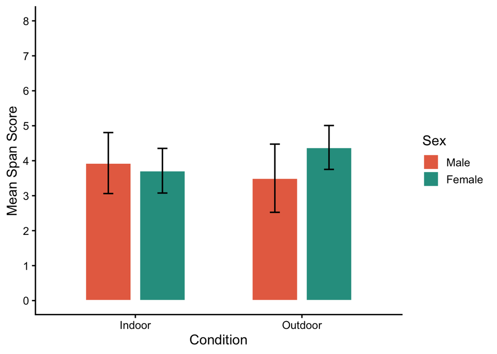

```r
p_span_condition_sex_bar <- ggplot(
  as.data.frame(emmeans(a1_span_sex, ~ condition * sex)),
  aes(
    x = condition,
    y = emmean,
    fill = sex
  )
) +
  geom_col(
    position = position_dodge(width = 0.65),
    width = 0.55,
    color = "white"
  ) +
  geom_errorbar(
    aes(
      ymin = lower.CL,
      ymax = upper.CL
    ),
    position = position_dodge(width = 0.65),
    width = 0.12,
    linewidth = 0.7
  ) +
  labs(
    x = "Condition",
    y = "Mean Span Score",
    fill = "Sex"
  ) +
  scale_fill_manual(
    values = c(
      "Male" = "#E76F51", # YOU CAN CHANGE THESE HEX VALUES TO MATCH YOUR POSTER!
      "Female" = "#2A9D8F"
    )
  ) +
  scale_y_continuous(
    breaks = seq(0, 8, 1)
  ) +
  coord_cartesian(
    ylim = c(0, 8)
  ) +
  theme_classic(
    base_size = 14
  )

p_span_condition_sex_bar
```

The figure shows estimated working memory scores by environmental condition and sex group. Error bars represent 95% confidence intervals.

### Span Score × Stress Interaction Plot

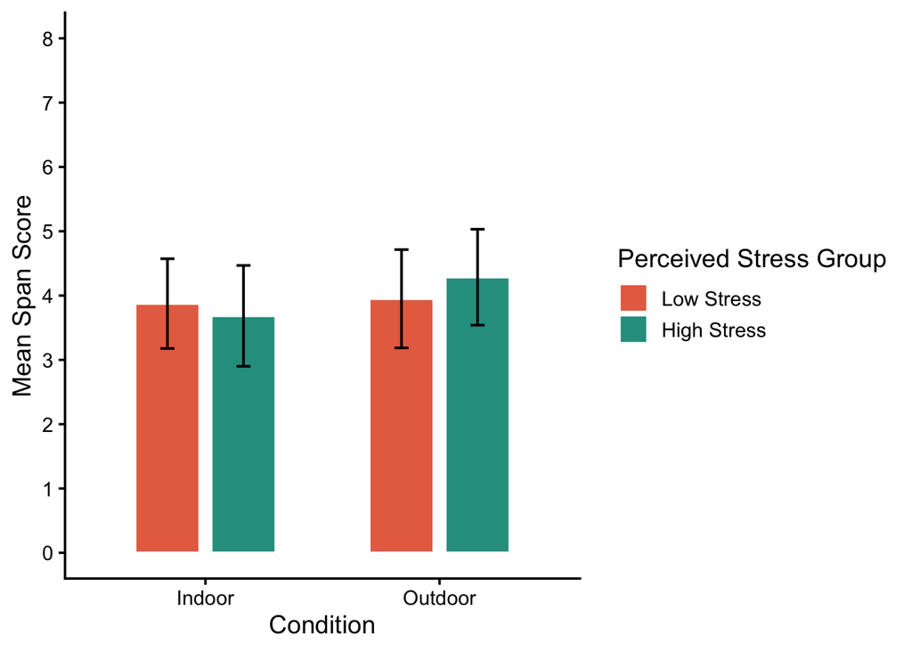

```r
p_span_condition_stress_bar <- ggplot(
  as.data.frame(emmeans(a2_span_stress, ~ condition * stress_group)),
  aes(
    x = condition,
    y = emmean,
    fill = stress_group
  )
) +
  geom_col(
    position = position_dodge(width = 0.65),
    width = 0.55,
    color = "white"
  ) +
  geom_errorbar(
    aes(
      ymin = lower.CL,
      ymax = upper.CL
    ),
    position = position_dodge(width = 0.65),
    width = 0.12,
    linewidth = 0.7
  ) +
  labs(
    x = "Condition",
    y = "Mean Span Score",
    fill = "Perceived Stress Group"
  ) +
  scale_fill_manual(
    values = c(
      "Low Stress" = "#E76F51",
      "High Stress" = "#2A9D8F"
    )
  ) +
  scale_y_continuous(
    breaks = seq(0, 8, 1)
  ) +
  coord_cartesian(
    ylim = c(0, 8)
  ) +
  theme_classic(
    base_size = 14
  )

p_span_condition_stress_bar
```

The figure shows estimated mean span scores by indoor and outdoor condition and perceived stress group. Error bars represent 95% confidence intervals.

### Export Figures

```r
if (!dir.exists("figures")) {
  dir.create("figures")
}

ggsave(
  filename = "figures/span_condition_sex_interaction_plot.svg",
  plot = p_span_condition_sex_bar,
  width = 7,
  height = 5
)

ggsave(
  filename = "figures/span_condition_stress_interaction_plot.svg",
  plot = p_span_condition_stress_bar,
  width = 7,
  height = 5
)
```

The figures were exported to the figures/folder so they can be used in manuscripys,poster, or repository materials.

## Results Summary

Results Summary The main analyses tested whether environmental condition, perceived stress group, and sex were related to working memory performance. In both ANOVA models, none of these factors had a statistically significant effect on backward digit span scores.

Environmental condition did not affect working memory performance, meaning there were no meaningful differences between participants tested indoors versus outdoors. Perceived stress group and sex also did not significantly predict working memory performance. In addition, none of the interaction effects were significant, showing that environmental condition did not relate to working memory differently depending on stress level or sex.

Overall, the results suggest that short exposure to an outdoor environment did not improve working memory in this sample, and differences in stress level or sex did not meaningfully change performance.